# Uso de la API del Covid19 con Pandas

La URL https://api.covid19api.com/countries

## Instalacion librerias

Instalamos gracias a `!pip` la libreria de pandas, una bilbioteca de software escrita para manipular y analizar datos en Python

```python
!pip install pandas
```

## Configuracion de Pandas

Configuramos panda como pd a la hora de importar la libreria

```python
import pandas as pd
```

## Crear variable

Asignamos a la variable URL, la dirección de la que queremos extraer los datos

```python
url = "https://api.covid19api.com/countries"
```

## Crear el dataframe

Creamos el dataframe que nos va a servir para visualizar la información del lugar del cual extraemos los datos

Por tanto decimos que el dataframe sea igual a la lectura que va a hacer pandas (que previamente lo hemos importado como pd), que lea los datos de la url con JSON (Java Script Object Notation)

Y decimos que nos muestre el dataframe poniendo df

```python
df = pd.read_json(url)
```

```python
df
```

|  | Country | Slug | ISO2 |
| --- | --- | --- | --- |
| 0 | French Polynesia | french-polynesia | PF |
| 1 | Indonesia | indonesia | ID |
| 2 | Malta | malta | MT |
| 3 | Sao Tome and Principe | sao-tome-and-principe | ST |
| 4 | Haiti | haiti | HT |
| ... | ... | ... | ... |
| 243 | Myanmar | myanmar | MM |
| 244 | Turkey | turkey | TR |
| 245 | Western Sahara | western-sahara | EH |
| 246 | Pitcairn | pitcairn | PN |
| 247 | Tanzania, United Republic of | tanzania | TZ |

248 rows × 3 columns

Por defecto al haber tantos datos, nos saldran los cinco primeros y los cinco últimos aunque se puede cambiar utilizando `df.head`o `df.tail` junto con el numero de resultado que queremos que salgan en parentesis (n)

## Exploración de la tabla

```python
df.head(6)
```

|  | Country | Slug | ISO2 |
| --- | --- | --- | --- |
| 0 | French Polynesia | french-polynesia | PF |
| 1 | Indonesia | indonesia | ID |
| 2 | Malta | malta | MT |
| 3 | Sao Tome and Principe | sao-tome-and-principe | ST |
| 4 | Haiti | haiti | HT |
| 5 | Poland | poland | PL |

```python
df.tail(2)
```

|  | Country | Slug | ISO2 |
| --- | --- | --- | --- |
| 246 | Pitcairn | pitcairn | PN |
| 247 | Tanzania, United Republic of | tanzania | TZ |

Para mostrar la información del dataframe utilizamos `df.info()` O para buscar en este caso el nombre en concreto de la lista `df["Country"]["N"]`

```python
df.info()
```

```
<class 'pandas.core.frame.DataFrame'>
RangeIndex: 248 entries, 0 to 247
Data columns (total 3 columns):
 #   Column   Non-Null Count  Dtype
---  ------   --------------  -----
 0   Country  248 non-null    object
 1   Slug     248 non-null    object
 2   ISO2     248 non-null    object
dtypes: object(3)
memory usage: 5.9+ KB
```

```python
df["Country"][66]
```

```
'Somalia'
```

## Tiempo real

https://api.covid19api.com/country/spain/status/confirmed/live

Ahora vamos a hacer el mismo ejercicio pero con un país en especifico

Creamos la variable de España en este caso tanto de los datos como del dataframe (url_es y df_es)

Igualamos la url a la dirección de la que queremos extraer los datos y el data frame a la lectura que queremos que haga pandas (previamente importado como pd) de la dirección de la que queremos extraer los datos gracias a JSON

Ponemos df_es para que nos muestre la visualizacion de los datos

```python
url_es = "https://api.covid19api.com/country/spain/status/confirmed/live"
df_es = pd.read_json(url_es)
df_es
```

|  | Country | CountryCode | Province | City | CityCode | Lat | Lon | Cases | Status | Date |
| --- | --- | --- | --- | --- | --- | --- | --- | --- | --- | --- |
| 0 | Spain | ES |  |  |  | 40.46 | -3.75 | 0 | confirmed | 2020-01-22 00:00:00+00:00 |
| 1 | Spain | ES |  |  |  | 40.46 | -3.75 | 0 | confirmed | 2020-01-23 00:00:00+00:00 |
| 2 | Spain | ES |  |  |  | 40.46 | -3.75 | 0 | confirmed | 2020-01-24 00:00:00+00:00 |
| 3 | Spain | ES |  |  |  | 40.46 | -3.75 | 0 | confirmed | 2020-01-25 00:00:00+00:00 |
| 4 | Spain | ES |  |  |  | 40.46 | -3.75 | 0 | confirmed | 2020-01-26 00:00:00+00:00 |
| ... | ... | ... | ... | ... | ... | ... | ... | ... | ... | ... |
| 798 | Spain | ES |  |  |  | 40.46 | -3.75 | 11508309 | confirmed | 2022-03-30 00:00:00+00:00 |
| 799 | Spain | ES |  |  |  | 40.46 | -3.75 | 11508309 | confirmed | 2022-03-31 00:00:00+00:00 |
| 800 | Spain | ES |  |  |  | 40.46 | -3.75 | 11551574 | confirmed | 2022-04-01 00:00:00+00:00 |
| 801 | Spain | ES |  |  |  | 40.46 | -3.75 | 11551574 | confirmed | 2022-04-02 00:00:00+00:00 |
| 802 | Spain | ES |  |  |  | 40.46 | -3.75 | 11551574 | confirmed | 2022-04-03 00:00:00+00:00 |

803 rows × 10 columns

Indagamos en la propia visualización de los datos investigando que tipo de datos nos muestra poniendo el df_es seguido de .columns

```python
df_es.columns
```

```
Index(['Country', 'CountryCode', 'Province', 'City', 'CityCode', 'Lat', 'Lon',
       'Cases', 'Status', 'Date'],
      dtype='object')
```

```python
df_es["Date"].head(1)
```

```
0   2020-01-22 00:00:00+00:00
Name: Date, dtype: datetime64[ns, UTC]
```

```python
df_es["Date"].tail(1)
```

```
802   2022-04-03 00:00:00+00:00
Name: Date, dtype: datetime64[ns, UTC]
```

```python
df_es.info()
```

```
<class 'pandas.core.frame.DataFrame'>
RangeIndex: 803 entries, 0 to 802
Data columns (total 10 columns):
 #   Column       Non-Null Count  Dtype
---  ------       --------------  -----
 0   Country      803 non-null    object
 1   CountryCode  803 non-null    object
 2   Province     803 non-null    object
 3   City         803 non-null    object
 4   CityCode     803 non-null    object
 5   Lat          803 non-null    float64
 6   Lon          803 non-null    float64
 7   Cases        803 non-null    int64
 8   Status       803 non-null    object
 9   Date         803 non-null    datetime64[ns, UTC]
dtypes: datetime64[ns, UTC](1), float64(2), int64(1), object(6)
memory usage: 62.9+ KB
```

En este caso le pedimos que el dataframe haga una descripción de los datos

```python
df_es.describe()
```

|  | Lat | Lon | Cases |
| --- | --- | --- | --- |
| count | 8.030000e+02 | 803.00 | 8.030000e+02 |
| mean | 4.046000e+01 | -3.75 | 3.242248e+06 |
| std | 7.109856e-15 | 0.00 | 3.109442e+06 |
| min | 4.046000e+01 | -3.75 | 0.000000e+00 |
| 25% | 4.046000e+01 | -3.75 | 3.186710e+05 |
| 50% | 4.046000e+01 | -3.75 | 3.149012e+06 |
| 75% | 4.046000e+01 | -3.75 | 4.920388e+06 |
| max | 4.046000e+01 | -3.75 | 1.155157e+07 |

En este caso le decimos que nos muestre los datos haciendo un índice de los datos clasificados por la fecha

```python
df_es.set_index("Date")
```

| Date | Country | CountryCode | Province | City | CityCode | Lat | Lon | Cases | Status |
| --- | --- | --- | --- | --- | --- | --- | --- | --- | --- |
| 2020-01-22 00:00:00+00:00 | Spain | ES |  |  |  | 40.46 | -3.75 | 0 | confirmed |
| 2020-01-23 00:00:00+00:00 | Spain | ES |  |  |  | 40.46 | -3.75 | 0 | confirmed |
| 2020-01-24 00:00:00+00:00 | Spain | ES |  |  |  | 40.46 | -3.75 | 0 | confirmed |
| 2020-01-25 00:00:00+00:00 | Spain | ES |  |  |  | 40.46 | -3.75 | 0 | confirmed |
| 2020-01-26 00:00:00+00:00 | Spain | ES |  |  |  | 40.46 | -3.75 | 0 | confirmed |
| ... | ... | ... | ... | ... | ... | ... | ... | ... | ... |
| 2022-03-30 00:00:00+00:00 | Spain | ES |  |  |  | 40.46 | -3.75 | 11508309 | confirmed |
| 2022-03-31 00:00:00+00:00 | Spain | ES |  |  |  | 40.46 | -3.75 | 11508309 | confirmed |
| 2022-04-01 00:00:00+00:00 | Spain | ES |  |  |  | 40.46 | -3.75 | 11551574 | confirmed |
| 2022-04-02 00:00:00+00:00 | Spain | ES |  |  |  | 40.46 | -3.75 | 11551574 | confirmed |
| 2022-04-03 00:00:00+00:00 | Spain | ES |  |  |  | 40.46 | -3.75 | 11551574 | confirmed |

803 rows × 9 columns

En este caso solo queremos que nos saque solamente la fecha y los casos que se ubican en los datos

```python
df_es.set_index("Date")["Cases"]
```

```
Date
2020-01-22 00:00:00+00:00           0
2020-01-23 00:00:00+00:00           0
2020-01-24 00:00:00+00:00           0
2020-01-25 00:00:00+00:00           0
2020-01-26 00:00:00+00:00           0
                               ...
2022-03-30 00:00:00+00:00    11508309
2022-03-31 00:00:00+00:00    11508309
2022-04-01 00:00:00+00:00    11551574
2022-04-02 00:00:00+00:00    11551574
2022-04-03 00:00:00+00:00    11551574
Name: Cases, Length: 803, dtype: int64
```

Teniendo en cuenta las funciones que hemos visto para ordenar y buscar los datos hacemos que se nos muestre el dataframe a través de un gráfico. Lo primero le decimos que nos saque las fechas y los casos de los datos leídos. Utilzamos `plot`para designar el gráfico y entre paréntesis indicamos el nombre de dicho grafico

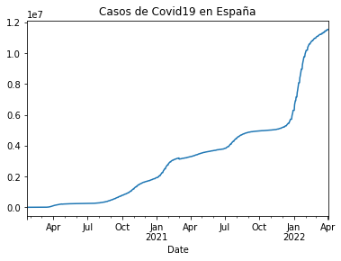

```python
df_es.set_index("Date")["Cases"].plot(title="Casos de Covid19 en España")
```

Ahora repetimos el mismo procedimiento con dos países más para hacer una comparación

## Otro País

```python
url_it = "https://api.covid19api.com/country/italy/status/confirmed/live"
df_it = pd.read_json(url_it)
df_it
```

|  | Country | CountryCode | Province | City | CityCode | Lat | Lon | Cases | Status | Date |
| --- | --- | --- | --- | --- | --- | --- | --- | --- | --- | --- |
| 0 | Italy | IT |  |  |  | 41.87 | 12.57 | 0 | confirmed | 2020-01-22 00:00:00+00:00 |
| 1 | Italy | IT |  |  |  | 41.87 | 12.57 | 0 | confirmed | 2020-01-23 00:00:00+00:00 |
| 2 | Italy | IT |  |  |  | 41.87 | 12.57 | 0 | confirmed | 2020-01-24 00:00:00+00:00 |
| 3 | Italy | IT |  |  |  | 41.87 | 12.57 | 0 | confirmed | 2020-01-25 00:00:00+00:00 |
| 4 | Italy | IT |  |  |  | 41.87 | 12.57 | 0 | confirmed | 2020-01-26 00:00:00+00:00 |
| ... | ... | ... | ... | ... | ... | ... | ... | ... | ... | ... |
| 798 | Italy | IT |  |  |  | 41.87 | 12.57 | 14567990 | confirmed | 2022-03-30 00:00:00+00:00 |
| 799 | Italy | IT |  |  |  | 41.87 | 12.57 | 14642354 | confirmed | 2022-03-31 00:00:00+00:00 |
| 800 | Italy | IT |  |  |  | 41.87 | 12.57 | 14719394 | confirmed | 2022-04-01 00:00:00+00:00 |
| 801 | Italy | IT |  |  |  | 41.87 | 12.57 | 14790806 | confirmed | 2022-04-02 00:00:00+00:00 |
| 802 | Italy | IT |  |  |  | 41.87 | 12.57 | 14845815 | confirmed | 2022-04-03 00:00:00+00:00 |

803 rows × 10 columns

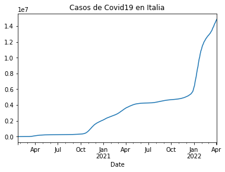

```python
df_it.set_index("Date")["Cases"].plot(title="Casos de Covid19 en Italia")
```

## Otro nuevo caso

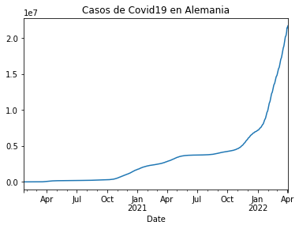

```python
url_ger = "https://api.covid19api.com/country/germany/status/confirmed/live"
df_ger = pd.read_json(url_ger)
df_ger.set_index("Date")["Cases"].plot(title="Casos de Covid19 en Alemania")
```

## Comparacion

Compararemos estos tres países en un solo gráfico

Lo primero creamos una variable para cada uno de los dataframe de los tres países que hemos escogido, en este caso España, Italia y Alemania

```python
casos_es = df_es.set_index("Date")["Cases"]
casos_it = df_it.set_index("Date")["Cases"]
casos_ger = df_ger.set_index("Date")["Cases"]
```

Creamos la variable de vs para visualizar los datos que igualamos a la concatenación de los dataframe de cada pais que hacemos gracias a panda por ello `pd.concat` Finalmente ponemos `axis=1`para ordenar los países en una sola fila Escribimos vs para mostranos la concatenacion de los datos

```python
vs = pd.concat([casos_es,casos_it,casos_ger],axis=1)
vs
```

| Date | Cases | Cases | Cases |
| --- | --- | --- | --- |
| 2020-01-22 00:00:00+00:00 | 0 | 0 | 0 |
| 2020-01-23 00:00:00+00:00 | 0 | 0 | 0 |
| 2020-01-24 00:00:00+00:00 | 0 | 0 | 0 |
| 2020-01-25 00:00:00+00:00 | 0 | 0 | 0 |
| 2020-01-26 00:00:00+00:00 | 0 | 0 | 0 |
| ... | ... | ... | ... |
| 2022-03-30 00:00:00+00:00 | 11508309 | 14567990 | 20829608 |
| 2022-03-31 00:00:00+00:00 | 11508309 | 14642354 | 21394747 |
| 2022-04-01 00:00:00+00:00 | 11551574 | 14719394 | 21394691 |
| 2022-04-02 00:00:00+00:00 | 11551574 | 14790806 | 21591147 |
| 2022-04-03 00:00:00+00:00 | 11551574 | 14845815 | 21706329 |

803 rows × 3 columns

Ahora las nombramos cada una de las columnas de vs como los nombres de los países

```python
vs.columns = ["España","Italia","Alemania"]
vs
```

| Date | España | Italia | Alemania |
| --- | --- | --- | --- |
| 2020-01-22 00:00:00+00:00 | 0 | 0 | 0 |
| 2020-01-23 00:00:00+00:00 | 0 | 0 | 0 |
| 2020-01-24 00:00:00+00:00 | 0 | 0 | 0 |
| 2020-01-25 00:00:00+00:00 | 0 | 0 | 0 |
| 2020-01-26 00:00:00+00:00 | 0 | 0 | 0 |
| ... | ... | ... | ... |
| 2022-03-30 00:00:00+00:00 | 11508309 | 14567990 | 20829608 |
| 2022-03-31 00:00:00+00:00 | 11508309 | 14642354 | 21394747 |
| 2022-04-01 00:00:00+00:00 | 11551574 | 14719394 | 21394691 |
| 2022-04-02 00:00:00+00:00 | 11551574 | 14790806 | 21591147 |
| 2022-04-03 00:00:00+00:00 | 11551574 | 14845815 | 21706329 |

803 rows × 3 columns

Para mostranos la visualizacion a través de un grafico utilizamos `plot`con la variable vs. Le ponemos titulo e indicamos el tipo de gráfico que queremos mostrar, en este caso un gráfico en el que se aprecie el área de cada uno de los países.

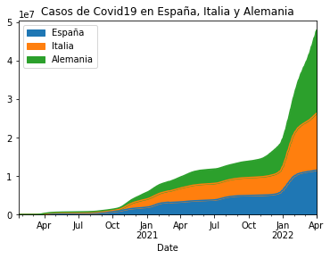

```python
vs.plot(title="Casos de Covid19 en España, Italia y Alemania", kind="area")
```

## Guardar el gráfico

Lo primero transformamos el grafico al formato de datos de csv y entre parentesis indicamos el nombre del archivo

```python
vs.to_csv("esvsit.csv")
```

Utilizamos la funcion `!ls`para comprobar si se ha guardado correctamente

```python
!ls
```

```
esvsit.csv			 python-prueba.ipynb  Shared_Resources
python-api-covid19-pandas.ipynb  seaborn-data
```

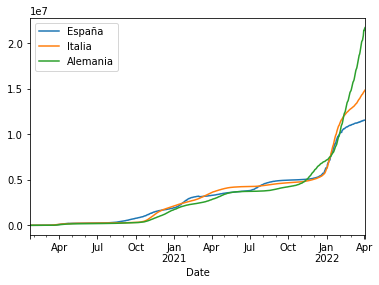

```python
import matplotlib.pyplot as plt
vs.plot()
plt.savefig("esvsit.png")
```

Comprobamos una última vez que todo esta guardado correctamente

```python
!ls
```

```
esvsit.csv  python-api-covid19-pandas.ipynb  seaborn-data
esvsit.png  python-prueba.ipynb		     Shared_Resources
```